# Getting all up in Brent’s biz - Getting to know you

```r
library(tidyverse)
library(dbplyr)
```

# Navigating the DB

## Available tables

```r
odbc::dbListTables(con, schema_name="anon")
```

```
 [1] "client_contact"
 [2] "client_sales"
 [3] "comments"
 [4] "mailchimp_clicks"
 [5] "mailchimp_members"
 [6] "mailchimp_opens"
 [7] "posts"
 [8] "users"
 [9] "usin_user_data"
[10] "woocommerce_order_items"
[11] "woocommerce_order_items_meta"
```

## Schema definitions

```r
(con %>%
  tbl(in_schema("information_schema","columns")) %>%
  select_all(str_to_lower) %>%
  select(table_name, column_name, is_nullable, data_type) %>%
  arrange(table_name, ordinal_position) %>%
  collect() ->
   schema)
```

| table_name | column_name | is_nullable | data_type |
| --- | --- | --- | --- |
| client_contact | email_domain_id | YES | int |
| client_contact | client_id | YES | int |
| client_sales | sale_date | YES | date |
| client_sales | transaction_type | YES | nvarchar |
| client_sales | num | YES | int |
| client_sales | product_service | YES | nvarchar |
| client_sales | quantity | YES | int |
| client_sales | sales_price | YES | int |
| client_sales | amount | YES | int |
| client_sales | client_id | YES | int |

[output cut: 95 more lines]

## Relationships

```r
schema %>%
  select(table_name, column_name) %>%
  group_by(column_name) %>%
  mutate(matches=n())%>%
  ungroup() %>%
  filter(matches>1)  ->
  schema_matches
schema_matches %>%
  spread(column_name, matches)
```

|  | table_name | click_timestamp | client_id | email_domain_id | email_user_id | id | order_item_id | region |
| --- | --- | --- | --- | --- | --- | --- | --- | --- |
| 1 | client_contact | NA | 2 | 7 | NA | NA | NA | NA |
| 2 | client_sales | NA | 2 | NA | NA | NA | NA | NA |
| 3 | comments | NA | NA | 7 | 6 | NA | NA | NA |
| 4 | database_firewall_rules | NA | NA | NA | NA | 3 | NA | NA |
| 5 | mailchimp_clicks | 2 | NA | 7 | 6 | NA | NA | NA |
| 6 | mailchimp_members | NA | NA | 7 | 6 | NA | NA | 2 |
| 7 | mailchimp_opens | 2 | NA | 7 | 6 | NA | NA | NA |
| 8 | posts | NA | NA | NA | NA | 3 | NA | NA |
| 9 | users | NA | NA | 7 | 6 | 3 | NA | NA |
| 10 | usin_user_data | NA | NA | NA | NA | NA | NA | 2 |

[output cut: 2 more lines]

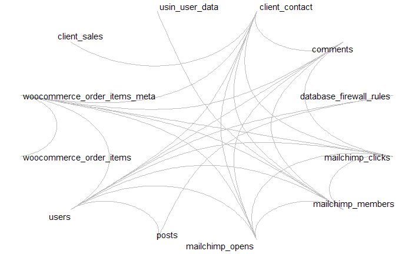

```r
library(igraph)
library(ggraph)
schema_matches %>%
  inner_join(schema_matches,by="column_name") %>%
  filter(table_name.x<table_name.y) %>%
  select(from=table_name.x, to=table_name.y) %>%
  graph_from_data_frame() %>%
  ggraph(layout="linear", circular=TRUE) +
  geom_edge_arc(colour="grey") +
  geom_node_text(aes(label = name), repel = TRUE) +
  theme_void()
```

# People

## Mailchimp

```r
con %>%
  tbl("mailchimp_members") ->
  mailchimp_members
mailchimp_members
```

| email_user_id | email_domain_id | signup_source | i_want_to_get | client_type | member_rating | optin_time | optin_ip | confirm_time | confirm_ip | latitude | longitude | gmt_off | dst_off | time_zone | country_code | region | last_changed | leid | euid | notes |
| --- | --- | --- | --- | --- | --- | --- | --- | --- | --- | --- | --- | --- | --- | --- | --- | --- | --- | --- | --- | --- |
| 81 | 47024 | Clients | NA | Membership Enterprise | 5 |  | NA | 2014-08-28 05:52:02 | NA | 41.0361 | '-74.7646000 | '-5 | '-4 | America/New_York | US | NJ | 2017-04-02 14:09:48 | 296267297 | ff15684877 | NA |
| 71 | 21490 | Clients | NA | Consulting, Membership Free | 2 |  | NA | 2014-08-28 05:52:34 | NA | 38.8945 | '-77.0741000 | '-5 | '-4 | America/New_York | US | VA | 2017-04-02 14:15:40 | 296269421 | 6ab1a10ff8 | NA |
| 97 | 29612 | Clients | NA | Consulting, Membership Free | 2 |  | NA | 2014-08-28 05:52:24 | NA | 33.7877 | '-84.4436000 | '-5 | '-4 | America/Kentucky/Monticello | US | GA | 2017-04-02 14:15:47 | 296268721 | 1b287ef2dd | NA |
| 125 | 44826 | Clients | NA | Training Conference Attendee | 4 |  | NA | 2017-10-26 04:39:40 | NA | 41.0355 | '-73.6282000 | '-5 | '-4 | America/New_York | US | CT | 2017-10-26 04:39:40 | 296684933 | 6ce09d27e8 | NA |
| 565 | 25325 | Clients | NA | Membership Performance | 4 |  | NA | 2016-01-07 14:03:27 | NA | 40.0293 | '-76.2656000 | '-5 | '-4 | America/New_York | US | PA | 2017-05-28 07:43:10 | 296466109 | 3c0c1fbdeb | NA |
| 266 | 15925 | Clients | NA | Consulting, Membership Enterprise | 1 |  | NA | 2014-08-08 09:08:17 | NA | 42.4233 | '-88.9929000 | '-5 | '-4 | America/Toronto | US | IL | 2017-11-25 07:52:11 | 296242321 | 2b3107462c | NA |
| 271 | 29737 | Clients | NA | Training Conference Attendee | 3 |  | NA | 2017-10-26 04:39:41 | NA | 40.9077 | '-73.8385000 | '-5 | '-4 | America/New_York | US | NY | 2017-10-26 04:39:41 | 296684953 | da0991de28 | NA |
| 371 | 27752 | Clients | NA | Consulting, Membership Enterprise | 5 |  | NA | 2014-08-28 17:38:23 | NA | 40.7488 | '-73.9964000 | '-5 | '-4 | America/New_York | US | NY | 2017-04-02 14:09:42 | 296285761 | 9c0f26660f | NA |
| 496 | 44912 | Clients | NA | Consulting, Membership Enterprise | 3 |  | NA | 2014-08-28 05:52:02 | NA | 40.3221 | '-86.9105000 | '-5 | '-4 | America/Indiana/Indianapolis | US | IN | 2017-04-02 14:09:42 | 296267281 | 0ef2beb9ac | NA |
| 4719 | 20 | Clients | NA | Membership Enterprise | 2 |  | NA | 2015-11-11 06:53:44 | NA | 42.8822 | '-78.8670000 | '-5 | '-4 | America/Toronto | US | NY | 2017-04-02 14:09:48 | 296447289 | 6b1f742d4a | NA |

[output cut: 990 more lines]

### Domains

We probably have a lot of personal email accounts. Based on [mailchimp’s 2015 analysis](https://blog.mailchimp.com/major-email-provider-trends-in-2015-gmail-takes-a-really-big-lead/), we might expect the most popular to be:

- gmail
- hotmail
- yahoo

```r
mailchimp_members %>%
  group_by(email_domain_id) %>%
  summarise(n=n()) %>%
  collect() ->
  domains
domains %>%
  top_n(10, n) %>%
  arrange(desc(n))
```

| email_domain_id | n |
| --- | --- |
| 19579 | 29204 |
| 21979 | 6131 |
| 52506 | 4805 |
| 35138 | 1381 |
| 27936 | 564 |
| 31546 | 332 |
| 21973 | 234 |
| 10345 | 234 |
| 52501 | 232 |
| 19861 | 174 |

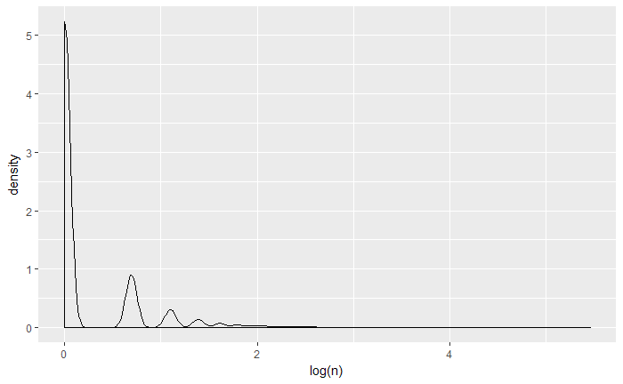

```r
library(ggplot2)
domains %>%
  filter(n<250) %>%
  ggplot(aes(x=log(n))) +
  geom_density()
```

I’m going to provisionally set some boundaries between public email domains, large companies, and small companies based on number of signups.

```r
read_csv("../data/EmailProviders.csv") %>%
  mutate(org_type="public") ->
  isps
domains %>%
  left_join(isps) %>%
  mutate(org_type= case_when(
    !is.na(org_type) ~ "public"
    ,n>20 ~ "large"
    ,TRUE ~ "small"
  )) ->
  domains
domains
```

| email_domain_id | n | org_type |
| --- | --- | --- |
| 23700 | 2 | small |
| 28632 | 7 | small |
| 15999 | 1 | small |
| 15361 | 2 | small |
| 19892 | 3 | small |
| 33630 | 1 | small |
| 10133 | 1 | small |
| 40865 | 1 | small |
| 13643 | 8 | small |
| 16764 | 2 | small |

[output cut: 990 more lines]

### Signup source

This indicates where people signed up or were loaded from.

```r
mailchimp_members %>%
  count(signup_source) %>%
  collect() %>%
  mutate(signup_sources=str_count(signup_source,", ")+1,
         all_signups=str_split(signup_source,", "),
         n=1) %>%
  unnest(all_signups) %>%
  mutate(all_signups=coalesce(all_signups,"Unknown source")) %>%
  spread(all_signups, n,fill = 0) ->
  signup_sources
signup_sources
```

|  | signup_source | signup_sources | 2017-05 Intersection Orlando Pre-Con | 2017-05 SQLDay Poland Pre-Con | 6-Month DBA Plan | Clients | Contact Form | Dell DBA Days 2016 | EBook-Setup | FeedBurner | First Responder Kit | iTunes Rating | MailOrderDBAs.com | Members | OptinMonster - BrentOzar.com | Sitewide Footer | SQLServerUpdates.com | Unknown Signup Source (Before 2014 Sept) | Unknown source | Watch Brent Tune Queries | Webcast Drawing | Webcast Registration |
| --- | --- | --- | --- | --- | --- | --- | --- | --- | --- | --- | --- | --- | --- | --- | --- | --- | --- | --- | --- | --- | --- | --- |
| 1 | 2017-05 Intersection Orlando Pre-Con | 1 | 1 | 0 | 0 | 0 | 0 | 0 | 0 | 0 | 0 | 0 | 0 | 0 | 0 | 0 | 0 | 0 | 0 | 0 | 0 | 0 |
| 2 | 2017-05 SQLDay Poland Pre-Con | 1 | 0 | 1 | 0 | 0 | 0 | 0 | 0 | 0 | 0 | 0 | 0 | 0 | 0 | 0 | 0 | 0 | 0 | 0 | 0 | 0 |
| 3 | 6-Month DBA Plan | 1 | 0 | 0 | 1 | 0 | 0 | 0 | 0 | 0 | 0 | 0 | 0 | 0 | 0 | 0 | 0 | 0 | 0 | 0 | 0 | 0 |
| 4 | 6-Month DBA Plan, Clients | 2 | 0 | 0 | 1 | 1 | 0 | 0 | 0 | 0 | 0 | 0 | 0 | 0 | 0 | 0 | 0 | 0 | 0 | 0 | 0 | 0 |
| 5 | 6-Month DBA Plan, Clients, OptinMonster - BrentOzar.com | 3 | 0 | 0 | 1 | 1 | 0 | 0 | 0 | 0 | 0 | 0 | 0 | 0 | 1 | 0 | 0 | 0 | 0 | 0 | 0 | 0 |
| 6 | 6-Month DBA Plan, EBook-Setup | 2 | 0 | 0 | 1 | 0 | 0 | 0 | 1 | 0 | 0 | 0 | 0 | 0 | 0 | 0 | 0 | 0 | 0 | 0 | 0 | 0 |
| 7 | 6-Month DBA Plan, EBook-Setup, Clients | 3 | 0 | 0 | 1 | 1 | 0 | 0 | 1 | 0 | 0 | 0 | 0 | 0 | 0 | 0 | 0 | 0 | 0 | 0 | 0 | 0 |
| 8 | 6-Month DBA Plan, EBook-Setup, First Responder Kit | 3 | 0 | 0 | 1 | 0 | 0 | 0 | 1 | 0 | 1 | 0 | 0 | 0 | 0 | 0 | 0 | 0 | 0 | 0 | 0 | 0 |
| 9 | 6-Month DBA Plan, EBook-Setup, First Responder Kit, Clients | 4 | 0 | 0 | 1 | 1 | 0 | 0 | 1 | 0 | 1 | 0 | 0 | 0 | 0 | 0 | 0 | 0 | 0 | 0 | 0 | 0 |
| 10 | 6-Month DBA Plan, EBook-Setup, First Responder Kit, SQLServerUpdates.com | 4 | 0 | 0 | 1 | 0 | 0 | 0 | 1 | 0 | 1 | 0 | 0 | 0 | 0 | 0 | 1 | 0 | 0 | 0 | 0 | 0 |

[output cut: 440 more lines]

### I want to get

This indicates what mailing list campaigns folks would like to receive.

```r
mailchimp_members %>%
  count(i_want_to_get) %>%
  collect() %>%
  mutate(i_want_to_gets=str_count(i_want_to_get,", ")+1,
         want_to_gets=str_split(i_want_to_get,", "),
         n=1) %>%
  unnest(want_to_gets) %>%
  mutate(want_to_gets=coalesce(want_to_gets,"Unknown")) %>%
  spread(want_to_gets, n,fill = 0) ->
  want_to_gets
want_to_gets
```

|  | i_want_to_get | i_want_to_gets | 2016-04 Early Access Coupon | 6-Month DBA Training Plan | Blog Posts | DBAreactions Tuesdays & Fridays | First Responder Kit Updates | Monday Links - our favorite SQL & tech news from the week | SQL Server Updates | Unknown |
| --- | --- | --- | --- | --- | --- | --- | --- | --- | --- | --- |
| 1 | 2016-04 Early Access Coupon | 1 | 1 | 0 | 0 | 0 | 0 | 0 | 0 | 0 |
| 2 | 6-Month DBA Training Plan | 1 | 0 | 1 | 0 | 0 | 0 | 0 | 0 | 0 |
| 3 | 6-Month DBA Training Plan, 2016-04 Early Access Coupon | 2 | 1 | 1 | 0 | 0 | 0 | 0 | 0 | 0 |
| 4 | 6-Month DBA Training Plan, Blog Posts | 2 | 0 | 1 | 1 | 0 | 0 | 0 | 0 | 0 |
| 5 | 6-Month DBA Training Plan, Blog Posts, SQL Server Updates | 3 | 0 | 1 | 1 | 0 | 0 | 0 | 1 | 0 |
| 6 | 6-Month DBA Training Plan, DBAreactions Tuesdays & Fridays | 2 | 0 | 1 | 0 | 1 | 0 | 0 | 0 | 0 |
| 7 | 6-Month DBA Training Plan, DBAreactions Tuesdays & Fridays, SQL Server Updates | 3 | 0 | 1 | 0 | 1 | 0 | 0 | 1 | 0 |
| 8 | 6-Month DBA Training Plan, SQL Server Updates | 2 | 0 | 1 | 0 | 0 | 0 | 0 | 1 | 0 |
| 9 | 6-Month DBA Training Plan, SQL Server Updates, 2016-04 Early Access Coupon | 3 | 1 | 1 | 0 | 0 | 0 | 0 | 1 | 0 |
| 10 | Blog Posts | 1 | 0 | 0 | 1 | 0 | 0 | 0 | 0 | 0 |

[output cut: 82 more lines]

### Member rating

This is a mailchimp defined feature based on how engaged subscribers are. It isn’t foolproof as it relies on people allowing the tracking pixels but it’s usually pretty good.

```r
mailchimp_members %>%
  count(member_rating) %>%
  mutate(prop=as.numeric(n)/sum(n)) %>%
  arrange(member_rating)
```

```
Missing values are always removed in SQL.
Use `sum(x, na.rm = TRUE)` to silence this warning
```

| member_rating | n | prop |
| --- | --- | --- |
| 1 | 1437 | 0.01450197 |
| 2 | 66607 | 0.67218690 |
| 3 | 5885 | 0.05939045 |
| 4 | 8029 | 0.08102735 |
| 5 | 17132 | 0.17289333 |

Two thirds of the members have relatively low engagement rates based on their member ratings.

### Location

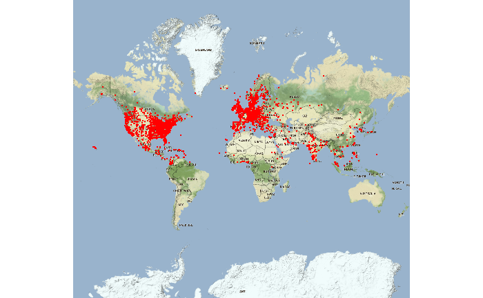

```r
library(ggmap)
mailchimp_members %>%
  collect() %>%
  mutate(longitude=as.numeric(str_replace(longitude,"'","")),
         latitude=as.numeric(str_replace(latitude,"'",""))) %>%
  {ggmap(get_stamenmap(bbox = c(left = -180, bottom = -80, right = 179.9999, top = 85), zoom = 3)) +
      geom_point(data=., aes(x=longitude, y=latitude), colour="red", size=.5) +
      theme_nothing()
  }
```

```r
mailchimp_members %>%
  count(country_code) %>%
  arrange(desc(n))
```

| country_code | n |
| --- | --- |
| US | 58973 |
| NA | 19575 |
| UK | 4697 |
| IN | 2357 |
| CA | 1602 |
| AU | 1313 |
| DE | 1099 |
| NL | 981 |
| SE | 641 |
| ZA | 543 |

[output cut: 160 more lines]

If using country code as a feature, we’ll need to add an explicit missing and lump together the smaller labels.

## Wordpress users

```r
con %>%
  tbl("users") ->
  wp_users
wp_users
```

| id | email_user_id | email_domain_id | user_registered | user_status |
| --- | --- | --- | --- | --- |
| 791 | 14733 | 19579 | 2017-03-27 18:06:57 | 0 |
| 18719 | 14734 | 19579 | 2017-05-26 11:19:57 | 0 |
| 13444 | 14738 | 19579 | 2017-04-04 19:42:40 | 0 |
| 792 | 14739 | 19579 | 2017-03-27 18:06:57 | 0 |
| 793 | 14740 | 19579 | 2017-03-27 18:06:57 | 0 |
| 794 | 14741 | 19579 | 2017-03-27 18:06:57 | 0 |
| 797 | 14746 | 19579 | 2017-03-27 18:06:58 | 0 |
| 798 | 14749 | 19579 | 2017-03-27 18:06:58 | 0 |
| 23993 | 14431 | 19579 | 2017-08-28 01:07:25 | 0 |
| 18025 | 14751 | 19579 | 2017-05-17 16:14:50 | 0 |

[output cut: 990 more lines]

### Mailchimp overlap

```r
mailchimp_members %>%
  full_join(wp_users, by="email_user_id",suffix=c(".m",".w")) %>%
  collect() %>%
  mutate(wp_match_type= case_when(
    !is.na(email_domain_id.m)& !is.na(email_domain_id.w) ~ "Both"
    , !is.na(email_domain_id.m) ~ "Mailchimp"
    , !is.na(email_domain_id.w) ~ "Wordpress"
  )) %>%
  select(email_user_id, wp_match_type) ->
  user_types
user_types %>%
  count(wp_match_type)
```

| wp_match_type | n |
| --- | --- |
| Both | 22817 |
| Mailchimp | 76273 |
| Wordpress | 4654 |

There are substantially more mailchimp subscribers than users who directly interact with the site in a signed up fashion. <5k are pure wordpress users. It will be interesting to see where profitability is. Assuming folks have to register on wordpress to purchase, then the Wordpress only bunch or the ones registered on both are likely to be the ones with purchases. The Wordpress only ones with purchases might be managers or people with authority to make purchases versus the engaged people who are the influencers/decision makers.

## Wordpress User Insight

```r
con %>%
  tbl("usin_user_data") ->
  wp_users_insight
wp_users_insight
```

| user_data_id | user_id | last_seen | sessions | country | region | city | coordinates | browser | browser_version | platform |
| --- | --- | --- | --- | --- | --- | --- | --- | --- | --- | --- |
| 5371 | 16749 | 2017-09-25 11:39:04 | 1 | United States | Indiana | Fort Wayne | 41.1569,-85.0556 | Chrome | 61.0.3163.100 | Windows |
| 5387 | 25185 | 2017-09-25 13:31:49 | 1 | United States | Louisiana | Zachary | 30.6379,-91.1797 | Chrome | 61.0.3163.100 | Windows |
| 5399 | 2071 | 2017-09-25 16:52:07 | 1 | United States | Illinois | Arlington Heights | 42.113,-87.9807 | Chrome | 61.0.3163.100 | Windows |
| 5542 | 25296 | 2017-09-27 09:42:40 | 1 | United States | New York | Fairport | 43.1005,-77.426 | Chrome | 61.0.3163.100 | Windows |
| 5544 | 25298 | 2017-09-27 10:15:36 | 1 | United States | California | Studio City | 34.1379,-118.3919 | Chrome | 61.0.3163.100 | Windows |
| 5559 | 25310 | 2017-09-27 14:17:00 | 1 | United States | Indiana | Indianapolis | 39.9115,-86.0706 | Chrome | 61.0.3163.100 | Windows |
| 5560 | 25311 | 2017-09-27 14:21:37 | 1 | United States | New Hampshire | Nashua | 42.7305,-71.4958 | Chrome | 61.0.3163.100 | Windows |
| 5591 | 25337 | 2017-09-28 06:26:24 | 1 | United States | California | Brea | 33.9167,-117.9001 | Chrome | 61.0.3163.100 | Windows |
| 5631 | 25370 | 2017-09-28 13:29:02 | 1 | United States | New York | Lancaster | 42.9057,-78.6264 | Chrome | 61.0.3163.100 | Windows |
| 5639 | 25374 | 2017-09-28 15:19:52 | 1 | United States | Ohio | Kent | 41.1352,-81.326 | Chrome | 61.0.3163.100 | Windows |

[output cut: 990 more lines]

### Locations

```r
wp_users_insight %>%
  count(country) %>%
  arrange(desc(n))
```

| country | n |
| --- | --- |
| United States | 4761 |
| United Kingdom | 1019 |
| unknown | 475 |
| Canada | 353 |
| India | 350 |
| Australia | 283 |
| Germany | 238 |
| Netherlands | 210 |
| South Africa | 157 |
| Sweden | 134 |

[output cut: 121 more lines]

Location data of wordpress users broadly matches the distribution of users in the mailing list.

### Engagement

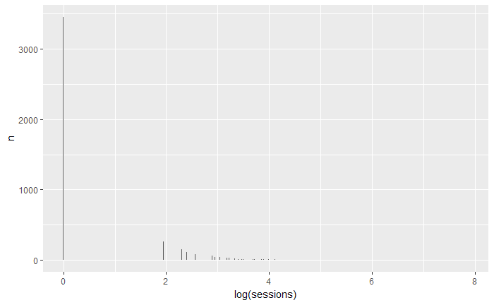

```r
wp_users_insight %>%
  count(sessions) %>%
  collect() %>%
  ggplot(aes(x=log(sessions), y=n), data=.)+
  geom_col()
```

```r
wp_users_insight %>%
  count(sessions) %>%
  collect() %>%
  mutate(prop=as.numeric(n)/sum(n) ) %>%
  arrange(desc(n),desc(sessions)) %>%
  mutate(cum_prop=cumsum(as.numeric(n)/sum(n)))
```

| sessions | n | prop | cum_prop |
| --- | --- | --- | --- |
| 1 | 3450 | 0.3476420798 | 0.3476421 |
| 2 | 1713 | 0.1726118501 | 0.5202539 |
| 3 | 986 | 0.0993550988 | 0.6196090 |
| 4 | 664 | 0.0669085046 | 0.6865175 |
| 5 | 521 | 0.0524989923 | 0.7390165 |
| 6 | 367 | 0.0369810560 | 0.7759976 |
| 7 | 265 | 0.0267029424 | 0.8027005 |
| 8 | 222 | 0.0223700121 | 0.8250705 |
| 9 | 172 | 0.0173317211 | 0.8424023 |
| 10 | 149 | 0.0150141072 | 0.8574164 |

[output cut: 135 more lines]

85% of registered users have 10 sessions or less.

### Devices

```r
wp_users_insight %>%
  count(browser, platform) %>%
  collect() %>%
  ungroup() %>%
  mutate(n=scales::percent(as.numeric(n)/sum(n))) %>%
  spread(platform, n, fill = "0%")
```

|  | browser | Android | Apple | iPad | iPhone | Linux | unknown | Windows |
| --- | --- | --- | --- | --- | --- | --- | --- | --- |
| 1 | Android | 0.0% | 0% | 0% | 0% | 0% | 0% | 0% |
| 2 | Chrome | 1.0% | 2.9% | 0.1% | 0.1% | 0.3% | 0.1% | 65.0% |
| 3 | Edge | 0% | 0% | 0% | 0% | 0% | 0% | 3.3% |
| 4 | Firefox | 0.0% | 0.3% | 0% | 0% | 0.3% | 0% | 10.6% |
| 5 | Internet Explorer | 0% | 0% | 0% | 0% | 0% | 0% | 12.9% |
| 6 | iPad | 0% | 0% | 0.4% | 0% | 0% | 0% | 0% |
| 7 | iPhone | 0% | 0% | 0% | 0.6% | 0% | 0% | 0% |
| 8 | Opera | 0.1% | 0.0% | 0% | 0% | 0.0% | 0% | 0.8% |
| 9 | Opera Mini | 0.0% | 0% | 0% | 0% | 0% | 0% | 0% |
| 10 | Safari | 0% | 1.3% | 0% | 0% | 0% | 0% | 0% |

[output cut: 1 more lines]

## Client contacts

```r
con %>%
  tbl("client_contact") ->
  client_contact
client_contact
```

| email_domain_id | client_id |
| --- | --- |
| 32 | 1 |
| 109 | 2 |
| 20821 | 3 |
| 8293 | 4 |
| 2316 | 5 |
| 523 | 6 |
| 525 | 7 |
| 535 | 8 |
| 577 | 9 |
| 829 | 10 |

[output cut: 644 more lines]

```r
client_contact %>%
  distinct() %>%
  left_join(mailchimp_members, by="email_domain_id", suffix=c(".c",".m")) %>%
  group_by(client_id,email_domain_id) %>%
  summarise(n=n_distinct(email_user_id)) %>%
  arrange(desc(n))
```

| client_id | email_domain_id | n |
| --- | --- | --- |
| 423 | 19579 | 29204 |
| 91 | 19579 | 29204 |
| 651 | 19579 | 29204 |
| 369 | 19579 | 29204 |
| 248 | 19579 | 29204 |
| 570 | 19579 | 29204 |
| 312 | 19579 | 29204 |
| 157 | 19579 | 29204 |
| 400 | 21979 | 6131 |
| 610 | 21979 | 6131 |

[output cut: 644 more lines]

It looks like there are a number of clients who transacted through public email domains. There are also clients without any mailchimp subscribers. When building feature, we will need to account for these facts.

```r
client_contact %>%
  distinct() %>%
  left_join(mailchimp_members, by="email_domain_id", suffix=c(".c",".m")) %>%
  group_by(client_id,email_domain_id) %>%
  summarise(n=n_distinct(email_user_id)) %>%
  filter(n<1)
```

| client_id | email_domain_id | n |
| --- | --- | --- |
| 551 | 377 | 0 |
| 151 | 12068 | 0 |
| 673 | 52356 | 0 |
| 62 | 5009 | 0 |
| 456 | 36339 | 0 |
| 523 | 41604 | 0 |
| 467 | 43973 | 0 |
| 193 | 15095 | 0 |
| 653 | 51090 | 0 |
| 102 | 8468 | 0 |

[output cut: 53 more lines]

## Training purchasers

** data not currently available **

## Students

In approximately 1/16th of training transactions - an address for a student has been provided.

```r
(con %>%
  tbl("woocommerce_order_items_meta") ->
  students)
```

| meta_id | order_item_id | meta_key | email_user_id | email_domain_id |
| --- | --- | --- | --- | --- |
| 62210 | 8550 | Student Email Address | 37 | 19579 |
| 62222 | 8551 | Student Email Address | 37 | 19579 |
| 62258 | 8554 | Student Email Address | 37 | 19579 |
| 62270 | 8555 | Student Email Address | 37 | 19579 |
| 32785 | 5090 | Student Email Address | 2905 | 19579 |
| 43827 | 6469 | Student Email Address | 3297 | 19579 |
| 31928 | 4995 | Student Email Address | 3910 | 19579 |
| 71912 | 9755 | Student Email Address | 5638 | 19579 |
| 74838 | 10134 | Student Email Address | 5638 | 19579 |
| 39182 | 5899 | Student Email Address | 6940 | 19579 |

[output cut: 502 more lines]

### Mailchimp overlap

```r
students %>%
  left_join(mailchimp_members, by="email_user_id", suffix=c(".s",".m")) %>%
  group_by(email_user_id) %>%
  summarise(n=n(), mailchimp=n_distinct(email_domain_id.m)) %>%
  group_by(mailchimp) %>%
  summarise(n=sum(n))
```

```
Missing values are always removed in SQL.
Use `SUM(x, na.rm = TRUE)` to silence this warning
```

| mailchimp | n |
| --- | --- |
| 0 | 86 |
| 1 | 426 |

# Training sales

## Posts

Training purchases partly end up in the `posts` table. The `posts` schema definition doesn’t play nice with the odbc driver. As a result, a subset of columns needs to be imported instead of live connected. We should also restrict to a specific post_type to save extraneous data.

```r
con %>%
  dbGetQuery("select
            id as post_id,
            post_date,
            post_date_gmt,
            post_name,
            post_status
            comment_count
            from anon.posts
            where post_type='shop_order'") ->
  posts
posts
```

| post_id | post_date | post_date_gmt | post_name | comment_count |
| --- | --- | --- | --- | --- |
| 26281 | 2017-03-26 14:08:04 | 2017-03-26 19:08:04 | order-mar-26-2017-0708-pm | wc-completed |
| 55296 | 2017-03-30 10:57:44 | 2017-03-30 15:57:44 | order-mar-30-2017-0219-pm | wc-completed |
| 55297 | 2017-03-30 11:26:29 | 2017-03-30 16:26:29 | order-mar-30-2017-0426-pm | wc-completed |
| 55336 | 2017-04-02 14:39:49 | 2017-04-02 19:39:49 | order-apr-02-2017-0739-pm | wc-completed |
| 55355 | 2017-04-02 20:54:31 | 2017-04-03 01:54:31 | order-apr-03-2017-0153-am | wc-completed |
| 55371 | 2017-04-02 21:13:01 | 2017-04-03 02:13:01 | order-apr-03-2017-0212-am | wc-completed |
| 55374 | 2017-04-02 21:22:41 | 2017-04-03 02:22:41 | order-apr-03-2017-0222-am | wc-completed |
| 55377 | 2017-04-02 21:27:18 | 2017-04-03 02:27:18 | order-apr-03-2017-0227-am | wc-completed |
| 55384 | 2017-04-02 22:49:47 | 2017-04-03 03:49:47 | order-apr-03-2017-0349-am | wc-completed |
| 55387 | 2017-04-02 23:07:35 | 2017-04-03 04:07:35 | order-apr-03-2017-0407-am | wc-completed |

[output cut: 990 more lines]

## Sales

The sales data is very basic without being able to see the extra meta table we’re waiting for.

```r
con %>%
  tbl("woocommerce_order_items") ->
  training_sales
training_sales
```

| order_item_id | order_item_name | order_item_type | order_id |
| --- | --- | --- | --- |
| 21 | Performance Tuning Training | line_item | 55360 |
| 55 | Performance Tuning Training | line_item | 55396 |
| 58 | Performance Tuning Training | line_item | 55397 |
| 99 | Performance Tuning Training | line_item | 55450 |
| 100 | Performance Tuning Training | line_item | 55451 |
| 115 | Performance Tuning Training | line_item | 55490 |
| 117 | Performance Tuning Training | line_item | 55491 |
| 135 | Performance Tuning Training | line_item | 55615 |
| 138 | Performance Tuning Training | line_item | 55616 |
| 157 | Performance Tuning Training | line_item | 55731 |

[output cut: 990 more lines]

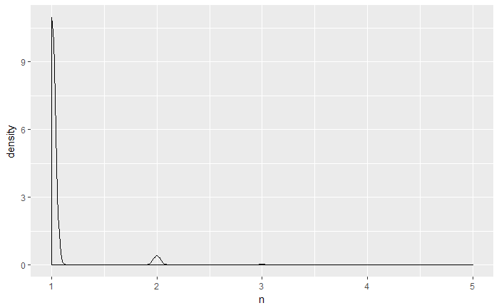

```r
training_sales %>%
  count(order_id) %>%
  collect() %>%
  ggplot(data=., aes(x=n)) +
  geom_density()
```

Most people order a single training item in one transaction.

```r
training_sales %>%
  count(order_id) %>%
  filter(n>1) %>%
  arrange(desc(n))
```

| order_id | n |
| --- | --- |
| 100156 | 5 |
| 101975 | 4 |
| 99421 | 4 |
| 100334 | 4 |
| 97833 | 4 |
| 101051 | 4 |
| 92301 | 4 |
| 101966 | 4 |
| 96754 | 4 |
| 96543 | 4 |

[output cut: 297 more lines]

```r
training_sales %>%
  count(order_item_name) %>%
  arrange(desc(n))
```

| order_item_name | n |
| --- | --- |
| Performance Tuning Training | 1594 |
| Free Membership | 1480 |
| Database Administration Training | 1368 |
| Recorded Class Season Pass | 1115 |
| Enterprise (Everything) | 1018 |
| SQL Critical CareÂ® Client Access | 568 |
| PASS Summit 2017: Expert Performance Tuning for SQL Server 2016 & 2017 | 350 |
| Enterprise (Everything Bundle) | 280 |
| 2018 Live Class Season Pass | 110 |
| Mastering Index Tuning - November 27-29, 2017 Online | 35 |

[output cut: 47 more lines]

*Need to fix this regex to get first two words*

```r
training_sales %>%
  collect() %>%
  mutate(highlevel_training= str_extract(
    str_to_lower(order_item_name),
    boundary("word"))) %>%
  count(highlevel_training) %>%
  arrange(desc(n))
```

| highlevel_training | n |
| --- | --- |
| performance | 1704 |
| free | 1480 |
| database | 1368 |
| enterprise | 1298 |
| recorded | 1115 |
| sql | 571 |
| pass | 350 |
| mastering | 131 |
| 2018 | 110 |
| expert | 98 |

[output cut: 5 more lines]

*Need to work out if the free training passes are sommething to be included as a desired outcome when building models*

## Sales over time

**Sales only starts in 2017?**

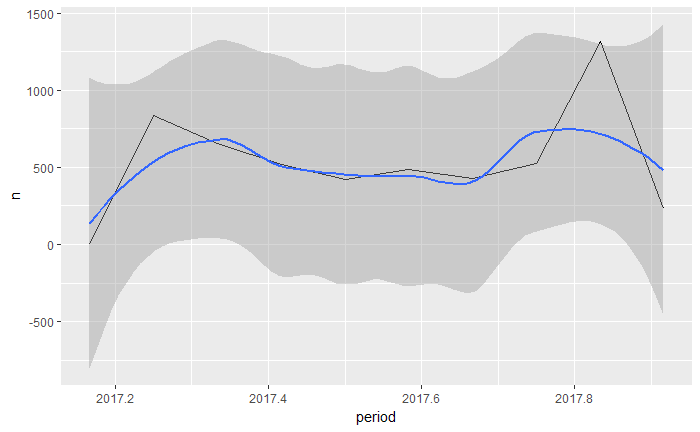

```r
posts %>%
  collect() %>%
  mutate(period=zoo::as.yearmon(post_date_gmt)) %>%
  count(period) ->
  monthly_training_sales
monthly_training_sales %>%
  ggplot(data=., aes(x=period, y=n)) +
  geom_line() +
  geom_smooth()
```

# Consultancy sales

```r
con %>%
  tbl("client_sales") ->
  client_sales
client_sales
```

| sale_date | transaction_type | num | product_service | quantity | sales_price | amount | client_id |
| --- | --- | --- | --- | --- | --- | --- | --- |
| 2015-01-02 | Invoice | 1361 | Consulting:Consulting, SQL Critical Care:zSQL Critical Care® Session (4 days) | 1 | 6995 | 6995 | 418 |
| 2015-01-02 | Invoice | 1362 | Consulting:Consulting, SQL Critical Care:zSQL Critical Care® Session (4 days) | 1 | 6995 | 6995 | 468 |
| 2014-01-06 | Invoice | 690 | Consulting:Consulting, SQL Critical Care:zSQL Critical Care® Session (4 days) | 1 | 6995 | 6995 | 420 |
| 2015-01-08 | Invoice | 1382 | Consulting:Consulting, SQL Critical Care:zSQL Critical Care® Session (4 days) | 1 | 6995 | 6995 | 310 |
| 2013-01-10 | Invoice | 280 | Consulting:Consulting, SQL Critical Care:zSQL Critical Care® Session (4 days) | 1 | 6995 | 6995 | 335 |
| 2014-01-10 | Invoice | 725 | Consulting:Consulting, SQL Critical Care:zSQL Critical Care® Session (4 days) | 1 | 6995 | 6995 | 370 |
| 2015-01-15 | Invoice | 1363 | Consulting:Consulting, SQL Critical Care:zSQL Critical Care® Session (4 days) | 1 | 6995 | 6995 | 158 |
| 2015-01-15 | Invoice | 1383 | Consulting:Consulting, SQL Critical Care:zSQL Critical Care® Session (4 days) | 1 | 6995 | 6995 | 488 |
| 2015-01-16 | Invoice | 1318 | Consulting:Consulting, SQL Critical Care:zSQL Critical Care® Session (4 days) | 1 | 6995 | 6995 | 546 |
| 2014-01-17 | Invoice | 730 | Consulting:Consulting, SQL Critical Care:zSQL Critical Care® Session (4 days) | 1 | 6995 | 6995 | 112 |

[output cut: 990 more lines]

## Exclusions

```r
client_sales %>%
  filter(transaction_type=="Invoice" & amount > 0 & !is.na(product_service)) ->
  client_sales_clean
```

```r
client_sales %>%
  filter(transaction_type!="Invoice" | amount < 0 | is.na(product_service))
```

| sale_date | transaction_type | num | product_service | quantity | sales_price | amount | client_id |
| --- | --- | --- | --- | --- | --- | --- | --- |
| 2017-01-13 | Invoice | 3114 | Consulting:Transaction Fee for Bank Wires | 1 | -40 | -40 | 427 |
| 2015-01-22 | Invoice | 1385 | Consulting:Transaction Fee for Bank Wires | 1 | -25 | -25 | 427 |
| 2016-02-09 | Invoice | 2361 | Consulting:Transaction Fee for Bank Wires | 1 | -27 | -27 | 287 |
| 2016-02-26 | Invoice | 2432 | Consulting:Transaction Fee for Bank Wires | 1 | -30 | -30 | 69 |
| 2017-03-16 | Invoice | 3239 | Consulting:Transaction Fee for Bank Wires | 1 | -25 | -25 | 645 |
| 2015-04-09 | Invoice | 1605 | Consulting:Transaction Fee for Bank Wires | 1 | -30 | -30 | 235 |
| 2016-04-19 | Invoice | 2463 | Consulting:Transaction Fee for Bank Wires | 1 | -25 | -25 | 154 |
| 2017-04-19 | Invoice | 3273 | Consulting:Transaction Fee for Bank Wires | 1 | -25 | -25 | 421 |
| 2017-04-21 | Invoice | 3289 | Consulting:Transaction Fee for Bank Wires | 1 | -10 | -10 | 535 |
| 2017-07-05 | Invoice | 3490 | Consulting:Transaction Fee for Bank Wires | 1 | -30 | -30 | 599 |

[output cut: 89 more lines]

## Products

```r
client_sales_clean %>%
  count(product_service)
```

| product_service | n |
| --- | --- |
| Consulting:Consulting, Package | 8 |
| Consulting:Consulting, Package:Builds and Migrations | 3 |
| Consulting:Consulting, Package:Candidate Screening | 12 |
| Consulting:Consulting, Package:Consulting, Ongoing DBA Services (Hours) | 47 |
| Consulting:Consulting, Package:Consulting, Onsite (Days) | 61 |
| Consulting:Consulting, Package:Consulting, Onsite (Hours) | 67 |
| Consulting:Consulting, Package:Consulting, Remote (Days) | 38 |
| Consulting:Consulting, Package:Consulting, Remote (Hours) | 311 |
| Consulting:Consulting, Package:Critical Care for ISV Clients - 1 Month Coverage | 1 |
| Consulting:Consulting, Package:Critical Care for ISV Clients - 6 Months Coverage | 6 |

[output cut: 83 more lines]

```r
client_sales_clean %>%
  collect() %>%
  mutate(product_type=case_when(
    str_detect(product_service,"Consulting") ~ "Consulting"
    ,str_detect(product_service,"Training") ~ "Training"
    ,TRUE ~ "Other"
  )) %>%
  count(product_type)
```

| product_type | n |
| --- | --- |
| Consulting | 1152 |
| Training | 228 |

*Should training be lumped into the training sales or are they special?*

*Do the different consulting packages need to be split out?*

## Recurring clients

```r
client_sales_clean %>%
  count(client_id) %>%
  arrange(desc(n))
```

| client_id | n |
| --- | --- |
| 408 | 69 |
| 493 | 51 |
| 97 | 31 |
| 469 | 26 |
| 365 | 22 |
| 441 | 21 |
| 144 | 21 |
| 226 | 18 |
| 174 | 18 |
| 275 | 16 |

[output cut: 623 more lines]

There are clients with ongoing work and we’ll want to decide how to handle these.

```r
client_sales_clean %>%
  filter(client_id==408)
```

| sale_date | transaction_type | num | product_service | quantity | sales_price | amount | client_id |
| --- | --- | --- | --- | --- | --- | --- | --- |
| 2011-10-26 | Invoice | 57 | Consulting:Consulting, SQL Critical Care:zHealth Check Hours | 1 | 6995 | 6995 | 408 |
| 2012-01-15 | Invoice | 87 | Consulting:Consulting, Package:Consulting, Ongoing DBA Services (Hours) | 1 | 200 | 200 | 408 |
| 2012-01-15 | Invoice | 87 | Consulting:Consulting, Package:Consulting, Ongoing DBA Services (Hours) | 1 | 200 | 200 | 408 |
| 2012-01-15 | Invoice | 87 | Consulting:Consulting, Package:Consulting, Ongoing DBA Services (Hours) | 1 | 200 | 200 | 408 |
| 2012-01-15 | Invoice | 87 | Consulting:Consulting, Package:Consulting, Ongoing DBA Services (Hours) | 1 | 200 | 200 | 408 |
| 2013-01-28 | Invoice | 284 | Consulting:Consulting, Package:Consulting, Remote (Hours) | 1 | 276 | 276 | 408 |
| 2013-01-28 | Invoice | 284 | Consulting:Consulting, Package:Consulting, Remote (Hours) | 1 | 276 | 276 | 408 |
| 2012-02-11 | Invoice | 98 | Consulting:Consulting, Package:Consulting, Ongoing DBA Services (Hours) | 1 | 200 | 200 | 408 |
| 2012-02-11 | Invoice | 98 | Consulting:Consulting, Package:Consulting, Ongoing DBA Services (Hours) | 1 | 200 | 200 | 408 |
| 2012-02-11 | Invoice | 98 | Consulting:Consulting, Package:Consulting, Ongoing DBA Services (Hours) | 1 | 200 | 200 | 408 |

[output cut: 59 more lines]

## Sales over time

```r
client_sales_clean %>%
  group_by(sale_date) %>%
  summarise(n=n(), quantity=sum(quantity), sales=sum(amount)) ->
  daily_sales
daily_sales %>%
  collect() %>%
  mutate(period=zoo::as.yearmon(sale_date)) %>%
  group_by(period) %>%
  summarise(n=sum(n), quantity=sum(quantity), sales=sum(sales)) ->
  monthly_sales
```

```
Missing values are always removed in SQL.
Use `SUM(x, na.rm = TRUE)` to silence this warningMissing values are always removed in SQL.
Use `SUM(x, na.rm = TRUE)` to silence this warning
```

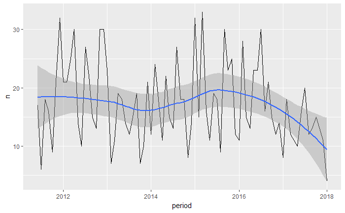

```r
monthly_sales %>%
  ggplot(data=., aes(x=period, y=n)) +
  geom_line() +
  geom_smooth()
```

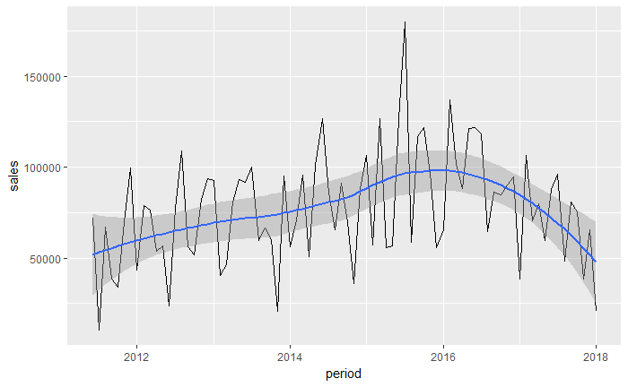

```r
monthly_sales %>%
  ggplot(data=., aes(x=period, y=sales)) +
  geom_line() +
  geom_smooth()
```

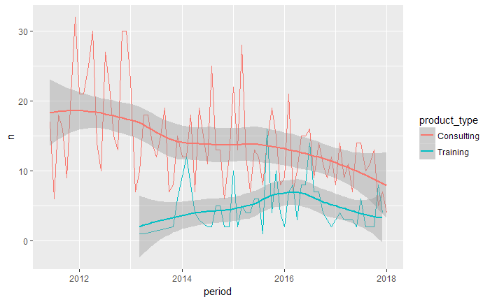

```r
client_sales_clean %>%
  collect() %>%
  mutate(product_type=case_when(
    str_detect(product_service,"Consulting") ~ "Consulting"
    ,str_detect(product_service,"Training") ~ "Training"
    ,TRUE ~ "Other"
  )) %>%
  mutate(period=zoo::as.yearmon(sale_date)) %>%
  group_by(period, product_type) %>%
  summarise(n=n(), quantity=sum(quantity), sales=sum(amount)) ->
  product_sales
product_sales %>%
  ggplot(data=., aes(x=period, y=n,
        group=product_type, colour=product_type)) +
  geom_line() +
  geom_smooth()
```

# Newsletter engagement

*Need campaign reports* *Need sent reports*

http://developer.mailchimp.com/documentation/mailchimp/reference/campaigns/#

## Opens

*Need campaign IDs*

```r
con %>%
  tbl("mailchimp_opens") ->
  mailchimp_opens
mailchimp_opens
```

| click_timestamp | email_user_id | email_domain_id |
| --- | --- | --- |
| 2013-10-14 13:37:52 | 68233 | 21161 |
| 2013-06-24 13:15:21 | 68233 | 21161 |
| 2012-08-06 12:29:06 | 68233 | 21161 |
| 2013-07-15 13:00:52 | 68233 | 21161 |
| 2012-10-01 14:07:22 | 68233 | 21161 |
| 2013-05-06 13:30:37 | 68233 | 21161 |
| 2012-04-09 14:04:10 | 68233 | 21161 |
| 2013-08-12 13:17:07 | 68233 | 21161 |
| 2012-06-11 12:03:43 | 68233 | 21161 |
| 2011-10-03 15:28:37 | 68233 | 21161 |

[output cut: 990 more lines]

### Opens over time

[figure not shown]

```r
mailchimp_opens %>%
  collect() %>%
  mutate(period=zoo::as.yearmon(click_timestamp)) %>%
  count(period) ->
  monthly_mailchimp_opens
monthly_mailchimp_opens %>%
  ggplot(data=., aes(x=period, y=n)) +
  geom_smooth()
```

## Clicks

*Need campaign IDs*

```r
con %>%
  tbl("mailchimp_clicks") %>%
  collect() ->
  mailchimp_clicks
mailchimp_clicks
```

| click_timestamp | email_user_id | email_domain_id | click_url |
| --- | --- | --- | --- |
| 2014-01-08 22:40:13 | 94658 | 2287 | http://www.brentozar.com/archive/2014/01/sql-server-dmvs-that-lie/ |
| 2014-01-09 12:00:31 | 83332 | 35448 | http://www.brentozar.com/archive/2014/01/sql-server-dmvs-that-lie/ |
| 2014-01-09 15:13:52 | 34628 | 22816 | https://www2.gotomeeting.com/register/289891170 |
| 2014-01-09 19:34:25 | 77811 | 38524 | https://attendee.gotowebinar.com/register/2563130184773573889 |
| 2014-01-09 20:04:01 | 77811 | 38524 | http://www.brentozar.com/archive/2014/01/sql-server-dmvs-that-lie/ |
| 2014-01-09 22:37:07 | 61044 | 8498 | http://www.brentozar.com/archive/2013/12/the-year-in-hadoop-2013/ |
| 2014-01-09 22:48:13 | 61044 | 8498 | https://attendee.gotowebinar.com/register/8889316570228550401 |
| 2014-01-09 22:48:41 | 61044 | 8498 | https://www2.gotomeeting.com/register/289891170 |
| 2014-01-10 13:24:31 | 24373 | 42045 | https://www2.gotomeeting.com/register/289891170 |
| 2014-01-13 14:43:54 | 55700 | 32004 | http://www.brentozar.com/archive/2014/01/sql-server-dmvs-that-lie/ |

[output cut: 990 more lines]

### Clicks over time

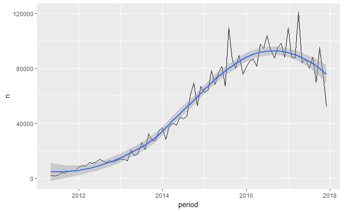

```r
mailchimp_clicks %>%
  mutate(period=zoo::as.yearmon(click_timestamp)) %>%
  count(period) ->
  monthly_mailchimp_clicks
monthly_mailchimp_clicks %>%
  ggplot(data=., aes(x=period, y=n)) +
  geom_line() +
  geom_smooth()
```

### Click destinations

```r
mailchimp_clicks %>%
  mutate(domain=urltools::domain(click_url)) %>%
  count(domain) %>%
  arrange(desc(n))
```

| domain | n |
| --- | --- |
| www.brentozar.com | 735888 |
| support.microsoft.com | 195782 |
| sqlblog.com | 109194 |
| www.youtube.com | 63626 |
| blogs.msdn.microsoft.com | 57554 |
| blogs.msdn.com | 54642 |
| dba.stackexchange.com | 53531 |
| msdn.microsoft.com | 49451 |
| learnfrom.brentozar.com | 49018 |
| github.com | 40540 |

[output cut: 990 more lines]